# FINAL_AUTO

## PRÁCTICA 3

## Librerias y Lectura de Datos

Lo primero importamos todas las librerías que van a ser necesarias para realizar la práctica.

```python
import numpy as np
import pandas as pd
import matplotlib.pyplot as plt
from sklearn.model_selection import train_test_split
from sklearn.preprocessing import StandardScaler
from sklearn.neighbors import KNeighborsRegressor
from sklearn.neighbors import KNeighborsClassifier
from sklearn.tree import DecisionTreeRegressor
from sklearn.metrics import r2_score
from sklearn.preprocessing import OneHotEncoder
from sklearn.metrics import accuracy_score, precision_score, recall_score, f1_score, classification_report, confusion_matrix
from sklearn.pipeline import Pipeline
from sklearn.impute import SimpleImputer
from sklearn.model_selection import GridSearchCV
from sklearn.compose import ColumnTransformer
from sklearn.tree import DecisionTreeClassifier
import seaborn as sns
from sklearn.feature_selection import VarianceThreshold
from sklearn.experimental import enable_iterative_imputer
from sklearn.impute import IterativeImputer
from sklearn.model_selection import TimeSeriesSplit, GridSearchCV
from sklearn.preprocessing import StandardScaler, RobustScaler, MaxAbsScaler
from sklearn.svm import SVR
from sklearn.ensemble import RandomForestRegressor
from xgboost import XGBRegressor
from joblib import dump
from google.colab import files
import warnings
warnings.filterwarnings("ignore")
```

### 1. Presentación de la base de datos y del problema

### 2. EDA

### 3. Preprocesado

### 4. Métodos No Ensembles

### 5. Métodos Ensembles

### 6. Predicción

### 7. Hyperban

# **1.Presentación de la base de datos y del problema**

Para realizar la siguiente práctica, contamos con una base de datos para tratar de predecir la radiación solar en plantas fotovoltaicas.

Contamos con una base de datos que contiene información acerca de 15 predictores meteorlógicos. Estos, además contienen a su vez mediciones tomadas a lo largo del día en 5 momentos concretos, lo que hace que al final nuestra base de datos cuente con 75 predictores.

Por otra parte, la variable "salida" hace referencia la radiación solar acumulada durante todo el día.

Además, hemos recogido datos a lo largo de un periodo de 12 años, y se han tomado medidas, durante este periodo de tiempo, cada uno de los días.

En lo que consistirá nuestra práctica será en construir modelos, en los que se seleccionarán los mejores hiperparámetros, además de los mejores métodos de preprocesado, para, usando todos los predictores que se han mencionado anteriormente, tratar de predecir de la mejor manera posible la situación meteorológica en un futuro aprevechándonos de esas estimaciones que tenemos como predicción de situaciones venideras.

A diferencia de otras prácticas, en esta afrontaremos problemas novedosos. Por ejemplo, se puede mencionar que en esta práctica, a diferencia de otras en las que imputaba utilizando el valor mediano de una variable, en esta por ejemplo ampliaremos nuestro abanico con una nueva técnica en la cual imputaremos con la técnica k- vecinos

```python
# Especifica la ruta del archivo Feather
archivo1 = '/content/drive/MyDrive/Automático/Practica3/compet.feather'
archivo2= '/content/drive/MyDrive/Automático/Practica3/disp.feather'
# Lee el archivo Feather con Pandas
datos1 = pd.read_feather(archivo1)
datos= pd.read_feather(archivo2)
# Ahora, 'datos' es un DataFrame de Pandas que contiene tus datos
print(datos1.head())
```

```
  apcp_sf1_1  apcp_sf2_1  apcp_sf3_1  apcp_sf4_1  apcp_sf5_1 dlwrf_s1_1  \
0        low         0.0         0.0         0.0         0.0       blue
1        low         0.0         NaN         0.0         0.0       blue
2        low         0.0         0.0         0.0         0.0        red
3        low         0.0         NaN         0.0         NaN       blue
4        low         0.0         0.0         0.0         0.0       None

  dlwrf_s2_1  dlwrf_s3_1 dlwrf_s4_1 dlwrf_s5_1  ...  ulwrf_t1_1  ulwrf_t2_1  \
0        low  275.618003     medium       blue  ...         0.0      medium
1        low  258.974701        low        red  ...         0.0      medium
2        low  262.735166     medium       None  ...         0.0      medium
3     medium  296.137074     medium       None  ...         0.0      medium
4        low  272.983784     medium        red  ...         0.0      medium

   ulwrf_t3_1 ulwrf_t4_1  ulwrf_t5_1  uswrf_s1_1  uswrf_s2_1  uswrf_s3_1  \
0        high       high  262.813816         NaN         low   48.000000
1      medium       high  255.737294         NaN         low   49.909091
2      medium     medium  217.005464         NaN         low   46.727273
3      medium       high  290.279308         NaN         low   44.454545
4        high       high  274.339575         NaN         low   47.545455

   uswrf_s4_1 uswrf_s5_1
0  105.727273  70.545455
1  109.181818        NaN
2   84.636364  57.727273
3  110.090909  76.000000
4  107.818182  74.727273

[5 rows x 75 columns]
```

Una vez cargados los datos, vamos a proceder a realizar un EDA en el cual observaremos distintos aspectos acerca de nuestros datos.

# **2. EDA**

Una vez presentada la base de datos, vamos a analizar nuestra base de datos. Cabe destacar que serán los datos "disp", ya que los datos "compet" serán usados para calcular predicciones sobre esos datos.

La finalidad de realizar un análisis exploratorio sobre los datos es que podremos ver y analizar que patrones y características tienen, ver el porcentaje de datos faltantes de cada variable..., antes de poder empezar a construir modelos y obtener predicciones.

```python
print(datos.head())
```

```
       salida apcp_sf1_1  apcp_sf2_1  apcp_sf3_1  apcp_sf4_1  apcp_sf5_1  \
0  12384900.0        low         0.0         0.0    0.000000    0.000000
1  11908500.0        low         0.0         0.0    0.017273    0.139091
2  12470700.0        low         0.0         0.0    0.000000    0.000000
3  12725400.0        low         0.0         0.0    0.000000    0.000000
4  10894800.0        low         0.0         0.0    0.000000    0.000000

  dlwrf_s1_1 dlwrf_s2_1  dlwrf_s3_1 dlwrf_s4_1  ... ulwrf_t1_1  ulwrf_t2_1  \
0       None        low  251.901758        low  ...        0.0        high
1       blue     medium  271.982095     medium  ...        0.0      medium
2        red        low  217.133093        low  ...        0.0      medium
3       blue        low  226.493584        low  ...        0.0      medium
4        red        low  249.123549     medium  ...        0.0      medium

   ulwrf_t3_1  ulwrf_t4_1  ulwrf_t5_1 uswrf_s1_1  uswrf_s2_1  uswrf_s3_1  \
0        high        high  260.522389        NaN         low   49.000000
1      medium      medium  232.871098        NaN         low   35.545455
2      medium      medium  246.802193        NaN         low   50.181818
3      medium      medium  250.140133        NaN         low   49.909091
4      medium      medium  244.200684        NaN         low   48.090909

   uswrf_s4_1  uswrf_s5_1
0  107.181818   73.545455
1   72.454545         NaN
2  110.727273         NaN
3  111.727273   77.272727
4  106.090909         NaN

[5 rows x 76 columns]
```

Lo primero, observamos que tenemos una base de datos que contamos con 76 variables. Salida es la variable que recoge la radiación solar acumulada durante todo el día. El resto de predictores son distintos fenómenos meteorológicos que se han recogido durante 5 horas concretas del día. Realmente, el número de variables que tenemos son 15, pero al tomar medidas de ellas 5 veces al día, se convierten en 75 .Como podemos observar, contamos tanto con variables categóricas como numéricas. Además, algunas de las columnas que podemos ver contienen valores faltantes, por tanto, habrá que tratarlas posteriormente.

```python
print(datos.salida)
```

```
0       12384900.0
1       11908500.0
2       12470700.0
3       12725400.0
4       10894800.0
           ...
4375    11276400.0
4376    11739600.0
4377    11870100.0
4378    11089500.0
4379     8790000.0
Name: salida, Length: 4380, dtype: float64
```

Visualizamos la variable salida por separado

```python
print(datos.shape)
print(datos.columns)
print(datos.dtypes)
print(datos.describe())
```

```
(4380, 76)
Index(['salida', 'apcp_sf1_1', 'apcp_sf2_1', 'apcp_sf3_1', 'apcp_sf4_1',
       'apcp_sf5_1', 'dlwrf_s1_1', 'dlwrf_s2_1', 'dlwrf_s3_1', 'dlwrf_s4_1',
       'dlwrf_s5_1', 'dswrf_s1_1', 'dswrf_s2_1', 'dswrf_s3_1', 'dswrf_s4_1',
       'dswrf_s5_1', 'pres_ms1_1', 'pres_ms2_1', 'pres_ms3_1', 'pres_ms4_1',
       'pres_ms5_1', 'pwat_ea1_1', 'pwat_ea2_1', 'pwat_ea3_1', 'pwat_ea4_1',
       'pwat_ea5_1', 'spfh_2m1_1', 'spfh_2m2_1', 'spfh_2m3_1', 'spfh_2m4_1',
       'spfh_2m5_1', 'tcdc_ea1_1', 'tcdc_ea2_1', 'tcdc_ea3_1', 'tcdc_ea4_1',
       'tcdc_ea5_1', 'tcolc_e1_1', 'tcolc_e2_1', 'tcolc_e3_1', 'tcolc_e4_1',
       'tcolc_e5_1', 'tmax_2m1_1', 'tmax_2m2_1', 'tmax_2m3_1', 'tmax_2m4_1',
       'tmax_2m5_1', 'tmin_2m1_1', 'tmin_2m2_1', 'tmin_2m3_1', 'tmin_2m4_1',
       'tmin_2m5_1', 'tmp_2m_1_1', 'tmp_2m_2_1', 'tmp_2m_3_1', 'tmp_2m_4_1',
       'tmp_2m_5_1', 'tmp_sfc1_1', 'tmp_sfc2_1', 'tmp_sfc3_1', 'tmp_sfc4_1',
       'tmp_sfc5_1', 'ulwrf_s1_1', 'ulwrf_s2_1', 'ulwrf_s3_1', 'ulwrf_s4_1',
       'ulwrf_s5_1', 'ulwrf_t1_1', 'ulwrf_t2_1', 'ulwrf_t3_1', 'ulwrf_t4_1',
       'ulwrf_t5_1', 'uswrf_s1_1', 'uswrf_s2_1', 'uswrf_s3_1', 'uswrf_s4_1',
       'uswrf_s5_1'],
      dtype='object')
salida         float64
apcp_sf1_1    category
apcp_sf2_1     float64
apcp_sf3_1     float64
apcp_sf4_1     float64
                ...
uswrf_s1_1     float64
uswrf_s2_1    category
uswrf_s3_1     float64
uswrf_s4_1     float64
uswrf_s5_1     float64
Length: 76, dtype: object
             salida   apcp_sf2_1   apcp_sf3_1   apcp_sf4_1   apcp_sf5_1  \
count  4.380000e+03  4380.000000  3504.000000  4380.000000  3767.000000
mean   1.687247e+07     0.241592     0.450221     0.251330     0.467992
std    7.924037e+06     1.062819     1.943508     0.983976     1.713311
min    7.206000e+05     0.000000     0.000000     0.000000     0.000000
25%    1.137892e+07     0.000000     0.000000     0.000000     0.000000
50%    1.695705e+07     0.000000     0.000000     0.000000     0.000000
75%    2.375048e+07     0.033636     0.078182     0.013636     0.045455
max    3.134790e+07    22.546364    32.670000    24.410000    35.470909

```

[output cut: 16 more lines]

```
50%     291.515123   381.992985   444.641027   437.036721         0.0
75%     300.705759   431.114186   494.795769   488.092401         0.0
max     312.978197   476.145333   571.158569   560.144282         0.0

        ulwrf_t5_1  uswrf_s1_1   uswrf_s3_1   uswrf_s4_1   uswrf_s5_1
count  4380.000000       482.0  4380.000000  4380.000000  3811.000000
mean    263.047956         0.0    75.930656   128.743607   101.531237
std      38.679321         0.0    30.180077    39.287358    35.126465
min     121.743743         0.0     2.363636     4.272727     2.727273
25%     244.973457         0.0    53.181818   110.340909    76.909091
50%     270.405656         0.0    79.090909   138.454545   107.454545
75%     291.828192         0.0   102.113636   156.363636   131.363636
max     332.185372         0.0   185.909091   446.272727   313.909091

[8 rows x 46 columns]
```

Lo primero que observamos al aplicar "datos.shape" es que contamos con 4380 filas y 76 columnas(como hemos visto antes). El número de filas se debe a que, como hemos mencionado, hemos recogido datos durante 12 años, y los datos que se toman son diarios. Por tanto, 12(años)*365(días al año)=4380 filas de datos. También podemos analizar cuales de nuestros predictores son númericos y cuales categoricas, estas últimas que tendrán que ser tratadas como factores.

Por último, dentro de las variables numéricas, vemos como es su distribución de cuartiles, y si llegan o no al total de 4380 datos que deberían tener.

### Histogramas

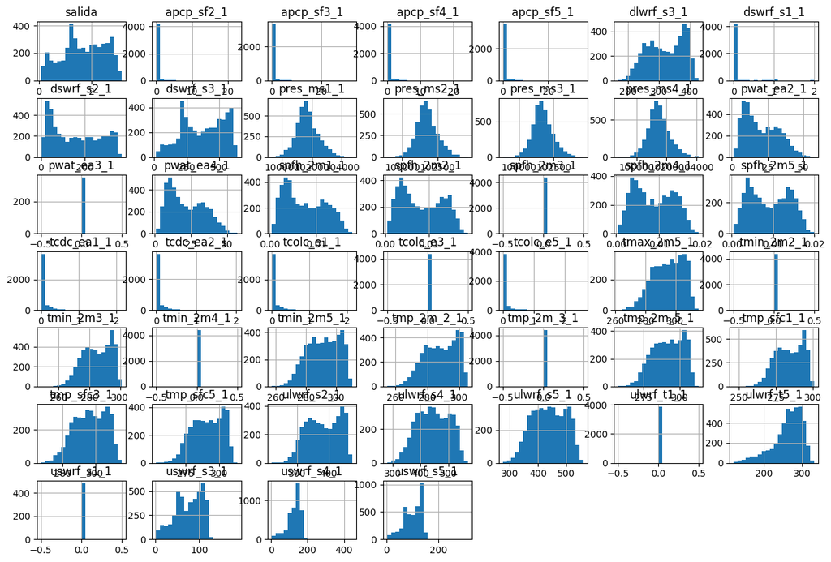

```python
datos.hist(bins=20,figsize=(15,10))
plt.show()
```

### Comprobación de valores faltantes

```python
missing_values_count=datos.isnull().sum()

missing_values_percent=100*missing_values_count/len(datos)

missing_values_datos = pd.DataFrame({'count' :missing_values_count , 'percent' :missing_values_percent})

missing_values_datos.sort_values('percent',ascending=False)
```

|  | count | percent |
| --- | --- | --- |
| pwat_ea3_1 | 4030 | 92.009132 |
| uswrf_s1_1 | 3898 | 88.995434 |
| apcp_sf3_1 | 876 | 20.000000 |
| tmp_sfc3_1 | 657 | 15.000000 |
| dlwrf_s5_1 | 657 | 15.000000 |
| ... | ... | ... |
| tcolc_e2_1 | 0 | 0.000000 |
| apcp_sf1_1 | 0 | 0.000000 |
| tcolc_e4_1 | 0 | 0.000000 |
| tcolc_e5_1 | 0 | 0.000000 |
| tcolc_e3_1 | 0 | 0.000000 |

76 rows × 2 columns

```python
missing_values_count=datos1.isnull().sum()

missing_values_percent=100*missing_values_count/len(datos1)

missing_values_datos1 = pd.DataFrame({'count' :missing_values_count , 'percent' :missing_values_percent})

missing_values_datos1.sort_values('percent',ascending=False)
```

|  | count | percent |
| --- | --- | --- |
| pwat_ea3_1 | 674 | 91.950887 |
| uswrf_s1_1 | 652 | 88.949523 |
| apcp_sf3_1 | 147 | 20.054570 |
| pres_ms2_1 | 110 | 15.006821 |
| tcdc_ea3_1 | 110 | 15.006821 |
| ... | ... | ... |
| apcp_sf2_1 | 0 | 0.000000 |
| tcolc_e4_1 | 0 | 0.000000 |
| tcolc_e5_1 | 0 | 0.000000 |
| tmax_2m1_1 | 0 | 0.000000 |
| tcolc_e3_1 | 0 | 0.000000 |

75 rows × 2 columns

Como podemos observar, tenemos en nuestra base de datos 2 columnas que presentan una cantidad de valores faltentes muy elevado, superando el 85% en ambos casos. El resto de las columnas presentan valores faltantes en un pocentaje de un 20% o menor, por tanto, estas últimas podrán ser tratadas de una forma distinta a la primera situación.

Para el segundo caso que hemos mencionado, es decir para aquellas variables cuyos faltantes no superan un 20% de los datos, se optará por la técnica de la imputación. Posteriormente se verá como con las variables numéricas imputaremos con la media, y con las variables categóricas imputaremos con la moda, es decir, el valor que más se repite.

```python
num_unique = datos.nunique()
const_cols = num_unique[num_unique == 1].index.tolist()

print(const_cols)
```

```
['pwat_ea3_1', 'spfh_2m3_1', 'tcolc_e3_1', 'tmin_2m2_1', 'tmin_2m4_1', 'tmp_2m_3_1', 'ulwrf_t1_1', 'uswrf_s1_1']
```

Mediante este código, extraemos aquellas variables de nuestra base de datos que presentan valores constantes. Usaremos esta identificación de variables posteriormente, ya que, por una parte, al ser constantes no aportan ninguna variabilidad al conjunto de datos, además de por ejemplo que el retirarlos significará un ahorro en cuanto al tiempo computacional que suponen. Por último, también se puede mencionar que el eliminarlas mejorará la interpretabilidad.

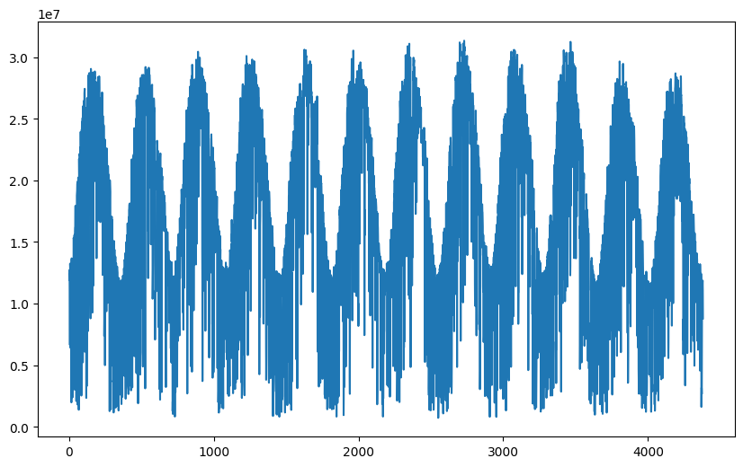

```python
tiempo = list(range(1, 365*12 + 1))
datos['tiempo'] = tiempo
plt.figure(figsize=(10, 6))
plt.plot(datos['tiempo'], datos['salida'], marker='', linestyle='-')
plt.show()
```

El último paso de EDA será realizar un gráfico en el que vemos como se distribuye la variable "tiempo" a lo largo de cada día y durante los 12 años que tenemos datos. En el gráfico, podemos observar lo siguiente. Se corresponde con la cantidad de radiación solar que recibe una placa fotovoltaica durante cada día de este largo período de tiempo. A pesar de que se observa un claro comportamiento estacional, es decir, todos los años la cantidad de radiación es muy similar, sin embargo parece que en los años séptimo y octavo de los 12 de los cuales tenemos datos presentan unos niveles de radiación mayor, ya que sus picos son algo mayores.

# **3.Prepocesado**

En esta primera parte, dividiremos los datos en train y test, eliminando previamente las variables que son constantes que hemos eliminado anteriormente. Además, también se eliminan aquellas que tienen un porcentaje mayor al 80% de datos faltantes.

Al hacer la división de train y test, usaremos 9 años de los 12 para el entrenamiento, mientras que los restantes 3 serán usados para evaluación. Esto se puede comprobar ya que, a la hora de realizar la función, test_size=0.25. Al introducir shuffle= False, los datos se dividen de forma continua sin reordenarlos. Esto es importante ya que como estamos trabajando con series temporales, es importante mantener el orden.

En esta parte, también se nos pide describir el coeficiente R^2, que es el que vamos a utilizar para comparar los modelos. Esta métrica hace referencia a qué porcentaje de la variabilidad total explican nuestras variables. Lo deseable será que esta medida sea lo más alta posible, para que nuestro modelo alcance la mayor variablidad posible. En los casos en los que este coeficiente se acerca mucho a uno, la medida será optima, aunque en los casos que supera un 0.75 ya se puede considerar como buena.

Aún asi, la medida del R^2 no es algo definitivo, sino que es preciso además tener en consideración otras métricas. Una de ellas podría ser el error cuadrático medio, ya que esta se centra en penalizar los errores individuales y resulta en información sobre la magnitud de los mismos( y además es más sensible en caso de existencia de outliers).

```python
x = datos.drop(['salida','pwat_ea3_1','uswrf_s1_1','pwat_ea3_1', 'spfh_2m3_1', 'tcolc_e3_1', 'tmin_2m2_1', 'tmin_2m4_1', 'tmp_2m_3_1', 'ulwrf_t1_1', 'uswrf_s1_1'], axis = 1)
y = datos['salida']
```

```python
X_train, X_test, Y_train, Y_test = train_test_split(x, y, test_size=0.25,shuffle=False)
```

Posteriormente, vamos a crear una pipeline que haga el preprocesado.

```python
imputer_learner_reg=KNeighborsRegressor()
imputer_learner_class= KNeighborsClassifier()


num_pipeline= Pipeline([

    ("imputer",IterativeImputer(estimator=imputer_learner_reg)),
    ("scaler",StandardScaler())
])

cat_pipeline= Pipeline([
    ("encoder",OneHotEncoder(sparse_output=False,handle_unknown="ignore")),

    ("imputer",IterativeImputer(estimator=imputer_learner_class))

])

preprocessor = ColumnTransformer([
    ("num", num_pipeline, ['apcp_sf2_1', 'apcp_sf3_1', 'apcp_sf4_1', 'apcp_sf5_1', 'dlwrf_s3_1', 'dswrf_s1_1', 'dswrf_s2_1', 'dswrf_s3_1', 'pres_ms1_1', 'pres_ms2_1', 'pres_ms3_1', 'pres_ms4_1', 'pwat_ea2_1', 'pwat_ea4_1', 'spfh_2m1_1', 'spfh_2m2_1', 'spfh_2m4_1', 'spfh_2m5_1', 'tcdc_ea1_1', 'tcdc_ea2_1', 'tcolc_e1_1', 'tcolc_e5_1', 'tmax_2m5_1', 'tmin_2m3_1', 'tmin_2m5_1', 'tmp_2m_2_1','tmp_2m_5_1', 'tmp_sfc1_1', 'tmp_sfc3_1', 'tmp_sfc5_1', 'ulwrf_s2_1', 'ulwrf_s4_1', 'ulwrf_s5_1', 'ulwrf_t5_1', 'uswrf_s3_1', 'uswrf_s4_1', 'uswrf_s5_1']), # Aplicar el pipeline numérico a las columnas numéricas
    ("cat", cat_pipeline,['apcp_sf1_1', 'dlwrf_s1_1', 'dlwrf_s2_1', 'dlwrf_s4_1', 'dlwrf_s5_1', 'dswrf_s4_1', 'dswrf_s5_1', 'pres_ms5_1', 'pwat_ea1_1', 'pwat_ea5_1', 'tcdc_ea3_1', 'tcdc_ea4_1', 'tcdc_ea5_1', 'tcolc_e2_1', 'tcolc_e4_1', 'tmax_2m1_1', 'tmax_2m2_1', 'tmax_2m3_1', 'tmax_2m4_1', 'tmin_2m1_1', 'tmp_2m_1_1', 'tmp_2m_4_1', 'tmp_sfc2_1', 'tmp_sfc4_1', 'ulwrf_s1_1', 'ulwrf_s3_1', 'ulwrf_t2_1', 'ulwrf_t3_1', 'ulwrf_t4_1', 'uswrf_s2_1']) # Aplicar el pipeline categórico a las columnas categóricas
])
```

KNeighborsRegressor y KNeighborsClassifier sirven como técnicas en la imputación iterativa de valores faltantes. KNeighborsRegressor se utiliza para variables numéricas, mientras que KNeighborsClassifier se utiliza para variables categóricas.

Porteriormente, se definen 2 pipelines, una para variables numéricas y otra para las categóricas. En la de numéricos, se imputa y se estandarizan las variables. Por otra parte, en la de categóricos, se codifican las variables mediante one-hot-encoder y se imputa.

Por último "ColumnTransformer" aplica los pipelines a las columnas específicas del DataFrame.

```python
preprocessor.fit(X_train)
```

```
ColumnTransformer(transformers=[('num',
                                 Pipeline(steps=[('imputer',
                                                  IterativeImputer(estimator=KNeighborsRegressor())),
                                                 ('scaler', StandardScaler())]),
                                 ['apcp_sf2_1', 'apcp_sf3_1', 'apcp_sf4_1',
                                  'apcp_sf5_1', 'dlwrf_s3_1', 'dswrf_s1_1',
                                  'dswrf_s2_1', 'dswrf_s3_1', 'pres_ms1_1',
                                  'pres_ms2_1', 'pres_ms3_1', 'pres_ms4_1',
                                  'pwat_ea2_1', 'pwat_ea4_1', 'spfh_2m1_1',
                                  'spfh_2...
                                  'dlwrf_s4_1', 'dlwrf_s5_1', 'dswrf_s4_1',
                                  'dswrf_s5_1', 'pres_ms5_1', 'pwat_ea1_1',
                                  'pwat_ea5_1', 'tcdc_ea3_1', 'tcdc_ea4_1',
                                  'tcdc_ea5_1', 'tcolc_e2_1', 'tcolc_e4_1',
                                  'tmax_2m1_1', 'tmax_2m2_1', 'tmax_2m3_1',
                                  'tmax_2m4_1', 'tmin_2m1_1', 'tmp_2m_1_1',
                                  'tmp_2m_4_1', 'tmp_sfc2_1', 'tmp_sfc4_1',
                                  'ulwrf_s1_1', 'ulwrf_s3_1', 'ulwrf_t2_1',
                                  'ulwrf_t3_1', 'ulwrf_t4_1', 'uswrf_s2_1'])])
```

En esta parte, preprocessor.fit(X_train) entrena el preprocesador a los datos de entrenamiento

```python
from sklearn.neighbors import KNeighborsRegressor
regressor=KNeighborsRegressor()
pipeline= Pipeline([
    ("preprocessor",preprocessor),
    ("regressor",regressor)
])

pipeline.fit(X_train,Y_train)
y_pred=pipeline.predict(X_test)

r2_score= r2_score(Y_test,y_pred)

print('El r2 para los parametros por defecto es :',r2_score)
```

```
El r2 para los parametros por defecto es : 0.7500853881453912
```

En este paso, se crea un pipeline mediante dos pasos, el preprocesador y el regresor k-NN. Pipeline.predict utiliza el pipeline entrenado para realizar predicciones en los datos test. Se aplica el mismo preprocesamiento que se utilizó en los datos train antes de hacer predicciones con el regresor k-NN. Luego, calcula el coeficiente de determinación R² comparando las predicciones "y_pred" con los datos "Y_test". El valor del R^2 indica como de bien ajustan las predicciones del modelo a los datos test.

El siguiente paso consistirá en buscar los hiperparámetros óptimos. Para ello, se usará GridSearch

```python
from sklearn.metrics import r2_score
imputer_learner_reg=KNeighborsRegressor()
imputer_learner_class= KNeighborsClassifier()


param_grid={
    "preprocessor__num__imputer": [IterativeImputer(estimator=imputer_learner_reg),SimpleImputer(strategy="mean")],
    "preprocessor__num__scaler": [StandardScaler(),RobustScaler(),MaxAbsScaler()],
    "preprocessor__cat__imputer": [IterativeImputer(estimator=imputer_learner_class),SimpleImputer(strategy="most_frequent")],
}

tscv= TimeSeriesSplit(n_splits=3)

grid_search= GridSearchCV(pipeline,param_grid, cv=tscv, scoring='r2')

grid_search.fit(X_train,Y_train)

print("Los mejores hiperparametros son:",grid_search.best_params_)

#Obtener el score del mejor modelo
score=grid_search.best_score_

print("El score del mejor modelo es:",score)

#Obtener el mejor modelo del grid search
best_model=grid_search.best_estimator_

#Predecir el conjunto de prueba con el mejor modelo
y_pred=best_model.predict(X_test)

#Calcular el r2 para y_test y_pred
r2= r2_score(Y_test,y_pred)

print('El r2 del mejor modelo es :',r2)
```

```
Los mejores hiperparametros son: {'preprocessor__cat__imputer': IterativeImputer(estimator=KNeighborsClassifier()), 'preprocessor__num__imputer': IterativeImputer(estimator=KNeighborsRegressor()), 'preprocessor__num__scaler': StandardScaler()}
El score del mejor modelo es: 0.7881002805257419
El r2 del mejor modelo es : 0.7500853881453912
```

Primeramente, se especifican posibles valores de hiperparámetros para explorar en el espacio de búsqueda. Estos incluyen opciones para el imputador numérico, el escalador numérico, y el imputador categórico. Después, mediante TimeSeriesSplit, cogemosun periodo de 6 años para entrenamiento y 3 años para luego evaluarlo. "grid_search" busca los mejores hiperparámetros y se especifica el objeto de validación cruzada "tscv", para luego ajustar el GridSearch a los datos.

Por último, se utilizan las predicciones del mejor modelo para evaluar el rendimiento en los datos de prueba, calculando el R^2, que es 75%

Antes de pasar al realizar los métodos ensamblados y no ensamblados, vamos a comparar las 2 técnicas de impitación que mencionábamos a la hora de realizar el EDA y que hemos aplicado ahora en el prepoceso.

Por una parte, la imputación de la mediana tiende a ser método que imputar la media ya que es menos sensible a datos atípicos. Tiene la ventaja respecto a Knn que es más simple y computacionalmente más sencillo. Sin embargo, si la estructura de los datos es más compleja no tiene porqué ser la mejor opción.

En cambio, el método Knn es más útil cuando los datos tienen una estructura compleja, pero es cierto que puede tener la complejidad de seleccionar adecuadamente el número de vecinos.

# **4.Métodos no ensambles**

Primero vamos a entrenar modelos no ensambles. Estos se entrenan de manera individual. Cada modelo es independiente, utilizando sus parámetros para obtener sus resultados.

La diversidad entre modelos no ensamblados se limita a las diferencias en sus propios parámetros internos y la variabilidad en los datos de entrenamiento que ven.

Cabe destacar que los métodos no ensamblados suelen ser más facilmente interpretables que los ensamblados y además, al no depender de otros modelos, suelen tener menos problemas en lo que a sobreajuste se refiere.

```python
# Crear Pipeline
regressor= KNeighborsRegressor()
pipeline= Pipeline([
    ("preprocessor",preprocessor),
    ("regressor",regressor)
])
```

```python
# Entrenar y evaluar el mejor metodo entre los no ensambles
param_grid={
    "regressor":[KNeighborsRegressor(),DecisionTreeRegressor(), SVR(kernel="linear"),SVR(kernel="rbf")]
}

#Crear un objeto TimeSeriesSplit en 3 carpetas para usar 6 años para entrenar y 3 años para evaluar
tscv= TimeSeriesSplit(n_splits=3)

#Crear un GridSearchCV con el estimador, el espacio de busqueda, la validacion cruzada y la metrica de evaluacion
grid_search= GridSearchCV(pipeline,param_grid, cv=tscv, scoring='r2')

#Ajustar el GridSearch a los datos
grid_search.fit(X_train,Y_train)

print("Los mejores hiperparametros son:",grid_search.best_params_)

#Obtener el score del mejor modelo
score=grid_search.best_score_

print("El score del mejor modelo es:",score)

#Obtener el mejor modelo del grid search
best_model=grid_search.best_estimator_

#Predecir el conjunto de prueba con el mejor modelo
y_pred=best_model.predict(X_test)

#Calcular el r2 para y_test y_pred
r2= r2_score(Y_test,y_pred)

print('El r2 del mejor modelo es :',r2)
```

```
Los mejores hiperparametros son: {'regressor': KNeighborsRegressor()}
El score del mejor modelo es: 0.7881002805257419
El r2 del mejor modelo es : 0.7500853881453912
```

Lo primero que realizamos es definir el espacio de búsqueda que incluye los regresores no ensamblados que debemos realizar, que son los siguientes:KNN, Árbol, SVM lineal y con kernel radial.

Los algoritmos KNN y árbol hemos trabajado con ellos más a menudo, basados en la búsqueda de K puntos más cercanos y en estructuras jerárquicas que se subdividen. Sin embargo SVM lineal y con kernel radial son más novedosos. El primero busca encontrar un hiperplano que mejor separe las clases en un espacio multidimensional, y se asume que los datos son linealmente separables. En cambio, SVM con kernel radial se puede realizar transformaciones no lineales en el espacio de características, permitiendo la clasificación de datos que no son linealmente separables en el espacio original.

Después, al igual que hemos realizado antes, realizamos validación cruzada en series temporales con 6 años para entrenamiento y 3 para evaluar, y buscamos los mejores hiperparámetros.

Después se evalúa el rendimiento y encontramos los mejores hiperparámetros con su correspondiente R^2.

Por último, se utilizan las predicciones del mejor modelo para evaluar el rendimiento en los datos de prueba, que es el último R^2. Además obtenemos que si ajuste de hiperparámetros el mejor el mejor modelo es k-vecinos.

```python
param_grid=[
  {
    #"preprocessor_num_imputer":[IterativeImputer(estimator=imputer_learner_reg),SimpleImputer(strategy="mean")]
    #"preprocessor_num_scaler":[StandardScaler(),RobustScaler(),MaxAbsScaler()],
    #"preprocessor_cat_imputer":[IterativeImputer(estimator=imputer_learner_class),SimpleImputer(strategy="most_frequent")],
    "regressor": [KNeighborsRegressor()],
    "regressor__n_neighbors" : [3,5,7]
  },
  {
    #"preprocessor_num_imputer":[IterativeImputer(estimator=imputer_learner_reg),SimpleImputer(strategy="mean")]
    #"preprocessor_num_scaler":[StandardScaler(),RobustScaler(),MaxAbsScaler()],
    #"preprocessor_cat_imputer":[IterativeImputer(estimator=imputer_learner_class),SimpleImputer(strategy="most_frequent")],
    "regressor":[DecisionTreeRegressor()],
    "regressor__max_depth":[2,4,6,10],
    "regressor__min_samples_split":[100,50,10]
  },
  {
    #"preprocessor_num_imputer":[IterativeImputer(estimator=imputer_learner_reg),SimpleImputer(strategy="mean")]
    #"preprocessor_num_scaler":[StandardScaler(),RobustScaler(),MaxAbsScaler()],
    #"preprocessor_cat_imputer":[IterativeImputer(estimator=imputer_learner_class),SimpleImputer(strategy="most_frequent")],
    "regressor":[SVR(kernel="linear")],
    "regressor__C":[0.1,1,10,100]
  },
  {
    #"preprocessor_num_imputer":[IterativeImputer(estimator=imputer_learner_reg),SimpleImputer(strategy="mean")]
    #"preprocessor_num_scaler":[StandardScaler(),RobustScaler(),MaxAbsScaler()],
    #"preprocessor_cat_imputer":[IterativeImputer(estimator=imputer_learner_class),SimpleImputer(strategy="most_frequent")],
    "regressor":[SVR(kernel="rbf")],
    "regressor__C":[0.1,1,10,100],
    "regressor__gamma":["scale","auto",0.0001,0.1,1,10]
  }
]
```

Después de lo realizado antes, vamos a probar cuales son los mejores hiperparámetros para K-vecinos, árbol, SVR con Kernel Lineal y SVR con Kernel Radial.

1. Para K-vecinos probamos con los valores 3,5 y 7.
2. Para árboles se busca la mejor profundidad máxima del árbol y el mejor número mínimo de muestras requeridas para dividir un nodo
3. Para SVR con Kernel Lineal se busca el mejor parámetro de regularización probando los valores 0.1, 1, 10 y 100 (controla la complejidad del modelo)
4. Para SVR con Kernel Radial se busca, al igual que antes, el mejor parámetro de regularización, y además el mejor parámetro de ancho del kernel ("scale" y "auto"). Este último sirve para controlar la forma y la flexibilidad del límite de decisión en SVM.

```python
#Explorar con un grid_search
#Crear un objeto TimeSeriesSplit en 3 carpetas para usar 6 años para entrenar y 3 años para evaluar
tscv= TimeSeriesSplit(n_splits=3)

#Crear un GridSearchCV con el estimador, el espacio de busqueda, la validacion cruzada y la metrica de evaluacion
grid_search= GridSearchCV(pipeline,param_grid, cv=tscv, scoring='r2')

#Ajustar el GridSearch a los datos
grid_search.fit(X_train,Y_train)

print("Los mejores hiperparametros son:",grid_search.best_params_)

#Obtener el score del mejor modelo
score=grid_search.best_score_

print("El score del mejor modelo es:",score)

#Obtener el mejor modelo del grid search
best_model=grid_search.best_estimator_

#Predecir el conjunto de prueba con el mejor modelo
y_pred=best_model.predict(X_test)

#Calcular el r2 para y_test y_pred
r2= r2_score(Y_test,y_pred)

print('El r2 del mejor modelo es :',r2)
```

```
Los mejores hiperparametros son: {'regressor': KNeighborsRegressor(n_neighbors=7), 'regressor__n_neighbors': 7}
El score del mejor modelo es: 0.7953041773184562
El r2 del mejor modelo es : 0.762910409245679
```

Podemos ver como nos muestra que de los 4 modelos que hemos realizado, el mejor de ellos es el método k-vecinos, el cual, dentro de los posibles hiperparámetros que habíamos seleccionado, el mejor es 7 vecinos. En el conjunto de prueba, obtenemos un R^2 del 76.291%. Se puede comprobar como, al realizar una búsqueda de hiperparámetros más exhaustiva, podemos mejorar el valor del R^2. Por lo tanto, podemos concluir que mejora tras el ajuste.

```python
# Importar las librerías necesarias
!pip install memory_profiler
import memory_profiler
import time
from sklearn.ensemble import AdaBoostClassifier
from sklearn.tree import DecisionTreeClassifier
from sklearn.model_selection import train_test_split, GridSearchCV
from sklearn.metrics import accuracy_score
from sklearn.pipeline import Pipeline
param_grid = {
    'regressor' : [KNeighborsRegressor(), DecisionTreeRegressor(), SVR(kernel='linear'), SVR(kernel='rbf')]
}
# Crear un objeto GridSearch con un cv=3
grid = GridSearchCV(pipeline, param_grid, cv=3)
# Decorar la función de entrenamiento con el decorador de memory_profiler
@memory_profiler.profile
def train_model(grid, X_train, Y_train):
    # Entrenar el modelo con el GridSearch con el conjunto de entrenamiento
    grid.fit(X_train, Y_train)

# Guardar el tiempo antes de ejecutar la función de entrenamiento
start_time = time.time()

# Ejecutar la función de entrenamiento
train_model(grid, X_train, Y_train)

# Guardar el tiempo después de ejecutar la función de entrenamiento
end_time = time.time()

# Calcular el tiempo de CPU total
cpu_time = end_time - start_time

# Mostrar el tiempo de CPU total
print(f"El tiempo de CPU total es {cpu_time:.2f} segundos")

# Obtener el diccionario de resultados de la validación cruzada
cv_results = grid.cv_results_
```

```
ERROR: Could not find file <ipython-input-81-c8b7d31c4374>
NOTE: %mprun can only be used on functions defined in physical files, and not in the IPython environment.
El tiempo de CPU total es 59.75 segundos
```

```python
# Mostrar el tiempo medio de ajuste y el tiempo medio de puntuación para cada configuración de parámetros
for i in range(len(cv_results["params"])):
    print(f"Configuración de parámetros {i+1}: {cv_results['params'][i]}")
    print(f"Tiempo medio de ajuste: {cv_results['mean_fit_time'][i]:.2f} segundos")
    print(f"Tiempo medio de puntuación: {cv_results['mean_score_time'][i]:.2f} segundos")
    print()
# Obtener el uso de memoria máximo durante la ejecución de la función de entrenamiento
max_memory = max(memory_profiler.memory_usage((train_model, (grid, X_train, Y_train))))

# Mostrar el uso de memoria máximo
print(f"El uso de memoria máximo es {max_memory:.2f} MiB")

# Mostrar los mejores parámetros encontrados por el GridSearch
print(f"Los mejores parámetros son: {grid.best_params_}")
```

```
Configuración de parámetros 1: {'regressor': KNeighborsRegressor()}
Tiempo medio de ajuste: 3.33 segundos
Tiempo medio de puntuación: 1.11 segundos

Configuración de parámetros 2: {'regressor': DecisionTreeRegressor()}
Tiempo medio de ajuste: 3.37 segundos
Tiempo medio de puntuación: 1.12 segundos

Configuración de parámetros 3: {'regressor': SVR(kernel='linear')}
Tiempo medio de ajuste: 3.11 segundos
Tiempo medio de puntuación: 1.29 segundos

Configuración de parámetros 4: {'regressor': SVR()}
Tiempo medio de ajuste: 3.12 segundos
Tiempo medio de puntuación: 1.07 segundos

ERROR: Could not find file <ipython-input-81-c8b7d31c4374>
NOTE: %mprun can only be used on functions defined in physical files, and not in the IPython environment.
El uso de memoria máximo es 2962.63 MiB
Los mejores parámetros son: {'regressor': KNeighborsRegressor()}
```

# **5.Métodos Ensambles**

Los modelos ensamblados, a diferencia de los anteriores no ensamblados que mencionábamos antes, estos sí combinan los distintos modelos para obtener resultados, lo que permite obtener información con mayor nivel de complejidad.

Los modelos ensamblados, a diferencia de los modelos no ensamblados que mencionábamos antes, se caracterizan por combinar múltiples modelos individuales para mejorar el conjunto. Estos métodos aprovechan la diversidad de diferentes modelos para abordar el problema y, por consiguiente, producir predicciones más precisas.

El término "ensamblado" se refiere a la idea de que estos modelos están construidos a partir de la agrupación de varios componentes.

```python
# Crear Pipeline
regressor= KNeighborsRegressor()
pipeline= Pipeline([
    ("preprocessor",preprocessor),
    ("regressor",regressor)
])
```

```python
from sklearn.model_selection import RandomizedSearchCV
from sklearn.ensemble import RandomForestClassifier
from sklearn.datasets import load_iris

#Entrenar y evaluar ensambles sin ajustar hiperparametros
param_grid={
  "regressor":[RandomForestRegressor(random_state=42),XGBRegressor(random_state=42)]
}

#Crear un objeto TimeSeriesSplit en 3 carpetas para usar 6 años para entrenar y 3 años para evaluar
tscv= TimeSeriesSplit(n_splits=3)

# Crear un objeto GridSearchCV para buscar los mejores hiperparámetros
grid_search = RandomizedSearchCV(pipeline, param_grid, cv=tscv, scoring="r2")

#Ajustar el GridSearch a los datos
grid_search.fit(X_train,Y_train)

print("Los mejores hiperparametros son:",grid_search.best_params_)

#Obtener el score del mejor modelo
score=grid_search.best_score_

print("El score del mejor modelo es:",score)

#Obtener el mejor modelo del grid search
best_model=grid_search.best_estimator_

#Predecir el conjunto de prueba con el mejor modelo
y_pred=best_model.predict(X_test)

#Calcular el r2 para y_test y_pred
r2= r2_score(Y_test,y_pred)

print('El r2 es :',r2)

import warnings
warnings.filterwarnings("ignore", category=DeprecationWarning)
```

```
Los mejores hiperparametros son: {'regressor': RandomForestRegressor(random_state=42)}
El score del mejor modelo es: 0.8246200337009025
El r2 es : 0.8139255674383261
```

Para los métodos ensamblados, al igual que hemos realizado con los métodos no ensamblados, vamos a explorar los diferentes modelos sin ajustar hiperparámetros específicos. En este caso, los modelos que vamos a realizar son los siguientes.

1. Random Forest: construye múltiples árboles de decisión durante el entrenamiento y combina sus predicciones, introduciendo aleatoriedad.
2. Boosting: crea un conjunto de árboles de forma secuencial, donde cada nuevo árbol corrige los errores del modelo existente

Vemos como en nuestro caso es mejor el método RandomForestRegressor que el método boosting, obteniendo un R^2 para este modelo del 81.392%

```python
# Importar las librerías necesarias
!pip install memory_profiler
import memory_profiler
import time
from sklearn.ensemble import AdaBoostClassifier
from sklearn.tree import DecisionTreeClassifier
from sklearn.model_selection import train_test_split, GridSearchCV
from sklearn.metrics import accuracy_score
from sklearn.pipeline import Pipeline
param_grid = {
   "regressor":[RandomForestRegressor(random_state=42),XGBRegressor(random_state=42)]
}
# Crear un objeto GridSearch con un cv=3
grid = GridSearchCV(pipeline, param_grid, cv=3)
# Decorar la función de entrenamiento con el decorador de memory_profiler
@memory_profiler.profile
def train_model(grid, X_train, Y_train):
    # Entrenar el modelo con el GridSearch con el conjunto de entrenamiento
    grid.fit(X_train, Y_train)

# Guardar el tiempo antes de ejecutar la función de entrenamiento
start_time = time.time()

# Ejecutar la función de entrenamiento
train_model(grid, X_train, Y_train)

# Guardar el tiempo después de ejecutar la función de entrenamiento
end_time = time.time()

# Calcular el tiempo de CPU total
cpu_time = end_time - start_time

# Mostrar el tiempo de CPU total
print(f"El tiempo de CPU total es {cpu_time:.2f} segundos")

# Obtener el diccionario de resultados de la validación cruzada
cv_results = grid.cv_results_
```

```
ERROR: Could not find file <ipython-input-85-61e528c68c8d>
NOTE: %mprun can only be used on functions defined in physical files, and not in the IPython environment.
El tiempo de CPU total es 84.37 segundos
```

```python
# Mostrar el tiempo medio de ajuste y el tiempo medio de puntuación para cada configuración de parámetros
for i in range(len(cv_results["params"])):
    print(f"Configuración de parámetros {i+1}: {cv_results['params'][i]}")
    print(f"Tiempo medio de ajuste: {cv_results['mean_fit_time'][i]:.2f} segundos")
    print(f"Tiempo medio de puntuación: {cv_results['mean_score_time'][i]:.2f} segundos")
    print()
# Obtener el uso de memoria máximo durante la ejecución de la función de entrenamiento
max_memory = max(memory_profiler.memory_usage((train_model, (grid, X_train, Y_train))))

# Mostrar el uso de memoria máximo
print(f"El uso de memoria máximo es {max_memory:.2f} MiB")

# Mostrar los mejores parámetros encontrados por el GridSearch
print(f"Los mejores parámetros son: {grid.best_params_}")
```

```
Configuración de parámetros 1: {'regressor': RandomForestRegressor(random_state=42)}
Tiempo medio de ajuste: 14.36 segundos
Tiempo medio de puntuación: 0.51 segundos

Configuración de parámetros 2: {'regressor': XGBRegressor(base_score=None, booster=None, callbacks=None,
             colsample_bylevel=None, colsample_bynode=None,
             colsample_bytree=None, device=None, early_stopping_rounds=None,
             enable_categorical=False, eval_metric=None, feature_types=None,
             gamma=None, grow_policy=None, importance_type=None,
             interaction_constraints=None, learning_rate=None, max_bin=None,
             max_cat_threshold=None, max_cat_to_onehot=None,
             max_delta_step=None, max_depth=None, max_leaves=None,
             min_child_weight=None, missing=nan, monotone_constraints=None,
             multi_strategy=None, n_estimators=None, n_jobs=None,
             num_parallel_tree=None, random_state=42, ...)}
Tiempo medio de ajuste: 5.84 segundos
Tiempo medio de puntuación: 0.44 segundos

ERROR: Could not find file <ipython-input-85-61e528c68c8d>
NOTE: %mprun can only be used on functions defined in physical files, and not in the IPython environment.
El uso de memoria máximo es 2962.94 MiB
Los mejores parámetros son: {'regressor': RandomForestRegressor(random_state=42)}
```

```python
#Con GridSearch
param_grid=[
  {
    "regressor": [RandomForestRegressor()],
    "regressor__n_estimators": [10,50,100,200],
    "regressor__max_features": [0.5,"sqrt","log2"]
  },
  {
    "regressor": [XGBRegressor(random_state=42)],
    "regressor__n_estimators": [10,50,100,200],
    "regressor__learning_rate": [0.01,0.1,0.2,0.3]
  },
]

#Crear un objeto TimeSeriesSplit en 3 carpetas para usar 6 años para entrenar y 3 años para evaluar
tscv= TimeSeriesSplit(n_splits=3)

# Crear un objeto GridSearchCV para buscar los mejores hiperparámetros
grid_search = RandomizedSearchCV(pipeline, param_grid, cv=tscv, scoring="r2")

#Ajustar el GridSearch a los datos
grid_search.fit(X_train,Y_train)

print("Los mejores hiperparametros son:",grid_search.best_params_)

#Obtener el score del mejor modelo
score=grid_search.best_score_

print("El score del mejor modelo es:",score)

#Obtener el mejor modelo del grid search
best_model=grid_search.best_estimator_

#Predecir el conjunto de prueba con el mejor modelo
y_pred=best_model.predict(X_test)

#Calcular el r2 para y_test y_pred
r2= r2_score(Y_test,y_pred)

print('El r2 del mejor modelo es :',r2)
```

```
Los mejores hiperparametros son: {'regressor__n_estimators': 200, 'regressor__max_features': 'sqrt', 'regressor': RandomForestRegressor(max_features='sqrt', n_estimators=200)}
El score del mejor modelo es: 0.8316251052204437
El r2 del mejor modelo es : 0.8234552429681385
```

Posteriormente ajustamos hiperparámetros para cada uno de los dos modelos.

En el caso de RandomForest, ajustamos el número de árboles y el número máximo de características que se deben considerar al dividir un nodo.

Para boosting, también ajustamos el número de árboles y la contribución de cada árbol al conjunto. Valores más bajos - más árboles para modelar relaciones complejas, pero pueden mejorar la generalización.

Podemos ver como RandomForest es el mejor de los dos métodos en nuestro caso, mostrandose cuales son los mejores hiperparámetros. En cuanto al R^2 ha mejorado en este caso con respecto a antes de ajustar hiperparámetros.

Por lo tanto, podemos afirmar al igual que pasaba con los métodos no ensamblados, que el resultado es mejor en ambos casos tras ajustar hiperparámetros.

Por tanto, comparando los modelos ensamblados y no ensamblados, el modelo mediante el cual obtenemos un mejor valor, una vez hemos ajustado hiperparámetros ,de R^2 es el RandomForest, por tanto concluimos que es nuestro mejor modelo final.

```python
#Con Random Search
from sklearn.model_selection import RandomizedSearchCV
```

```python
#Entrenar el mejor modelo con todos los datos
#Aplicar las mismas transformaciones de preprocesamiento
X_transformed=best_model[:-1].transform(x)

#Ajustar el mejor modelo con el conjutno de datos completo
best_model[-1].fit(X_transformed,y)

#Guardar el modelo entrenado en un archivo
dump(best_model,"best_model.joblib")
files.download('best_model.joblib')
```

En esta parte entrenamos el mejor modelo con todos los datos, ajustamos el mejor modelo y guardamos este último modelo final. Esta parte tiene su importancia ya que al entrenar el modelo con una cantidad de datos mayor, el entrenamiento será mas eficiente. Esto se debe a que la generalización mejora al no adaptarse tanto solo a los datos train y se optimizan los hiperparámetros

# **6. Cargar y Analizar el fichero para predicciones**

## EDA del conjunto de Datos Compet

En esta parte de predicción tenemos que, usando los datos que teníamos reservados para evaluar, que son los 3 últimos años, construir un modelo final para evaluarlo sobre los datos "compet.feather"

```python
print(datos1.head())
```

```
  apcp_sf1_1  apcp_sf2_1  apcp_sf3_1  apcp_sf4_1  apcp_sf5_1 dlwrf_s1_1  \
0        low         0.0         0.0         0.0         0.0       blue
1        low         0.0         NaN         0.0         0.0       blue
2        low         0.0         0.0         0.0         0.0        red
3        low         0.0         NaN         0.0         NaN       blue
4        low         0.0         0.0         0.0         0.0       None

  dlwrf_s2_1  dlwrf_s3_1 dlwrf_s4_1 dlwrf_s5_1  ...  ulwrf_t1_1  ulwrf_t2_1  \
0        low  275.618003     medium       blue  ...         0.0      medium
1        low  258.974701        low        red  ...         0.0      medium
2        low  262.735166     medium       None  ...         0.0      medium
3     medium  296.137074     medium       None  ...         0.0      medium
4        low  272.983784     medium        red  ...         0.0      medium

   ulwrf_t3_1 ulwrf_t4_1  ulwrf_t5_1  uswrf_s1_1  uswrf_s2_1  uswrf_s3_1  \
0        high       high  262.813816         NaN         low   48.000000
1      medium       high  255.737294         NaN         low   49.909091
2      medium     medium  217.005464         NaN         low   46.727273
3      medium       high  290.279308         NaN         low   44.454545
4        high       high  274.339575         NaN         low   47.545455

   uswrf_s4_1 uswrf_s5_1
0  105.727273  70.545455
1  109.181818        NaN
2   84.636364  57.727273
3  110.090909  76.000000
4  107.818182  74.727273

[5 rows x 75 columns]
```

```python
print(datos1.shape)
print(datos1.columns)
print(datos1.dtypes)
print(datos1.describe())
```

```
(733, 75)
Index(['apcp_sf1_1', 'apcp_sf2_1', 'apcp_sf3_1', 'apcp_sf4_1', 'apcp_sf5_1',
       'dlwrf_s1_1', 'dlwrf_s2_1', 'dlwrf_s3_1', 'dlwrf_s4_1', 'dlwrf_s5_1',
       'dswrf_s1_1', 'dswrf_s2_1', 'dswrf_s3_1', 'dswrf_s4_1', 'dswrf_s5_1',
       'pres_ms1_1', 'pres_ms2_1', 'pres_ms3_1', 'pres_ms4_1', 'pres_ms5_1',
       'pwat_ea1_1', 'pwat_ea2_1', 'pwat_ea3_1', 'pwat_ea4_1', 'pwat_ea5_1',
       'spfh_2m1_1', 'spfh_2m2_1', 'spfh_2m3_1', 'spfh_2m4_1', 'spfh_2m5_1',
       'tcdc_ea1_1', 'tcdc_ea2_1', 'tcdc_ea3_1', 'tcdc_ea4_1', 'tcdc_ea5_1',
       'tcolc_e1_1', 'tcolc_e2_1', 'tcolc_e3_1', 'tcolc_e4_1', 'tcolc_e5_1',
       'tmax_2m1_1', 'tmax_2m2_1', 'tmax_2m3_1', 'tmax_2m4_1', 'tmax_2m5_1',
       'tmin_2m1_1', 'tmin_2m2_1', 'tmin_2m3_1', 'tmin_2m4_1', 'tmin_2m5_1',
       'tmp_2m_1_1', 'tmp_2m_2_1', 'tmp_2m_3_1', 'tmp_2m_4_1', 'tmp_2m_5_1',
       'tmp_sfc1_1', 'tmp_sfc2_1', 'tmp_sfc3_1', 'tmp_sfc4_1', 'tmp_sfc5_1',
       'ulwrf_s1_1', 'ulwrf_s2_1', 'ulwrf_s3_1', 'ulwrf_s4_1', 'ulwrf_s5_1',
       'ulwrf_t1_1', 'ulwrf_t2_1', 'ulwrf_t3_1', 'ulwrf_t4_1', 'ulwrf_t5_1',
       'uswrf_s1_1', 'uswrf_s2_1', 'uswrf_s3_1', 'uswrf_s4_1', 'uswrf_s5_1'],
      dtype='object')
apcp_sf1_1    category
apcp_sf2_1     float64
apcp_sf3_1     float64
apcp_sf4_1     float64
apcp_sf5_1     float64
                ...
uswrf_s1_1     float64
uswrf_s2_1    category
uswrf_s3_1     float64
uswrf_s4_1     float64
uswrf_s5_1     float64
Length: 75, dtype: object
       apcp_sf2_1  apcp_sf3_1  apcp_sf4_1  apcp_sf5_1  dlwrf_s3_1  dswrf_s1_1  \
count  733.000000  586.000000  733.000000  630.000000  733.000000  733.000000
mean     0.250981    0.554502    0.396790    0.805700  325.091814    0.057299
std      0.851373    1.856470    1.512354    2.989286   59.489724    0.232426
min      0.000000    0.000000    0.000000    0.000000  196.875147    0.000000
25%      0.000000    0.000000    0.000000    0.000000  274.918291    0.000000
50%      0.000000    0.000000    0.000000    0.000000  330.237319    0.000000
75%      0.060000    0.182045    0.047273    0.196364  378.975034    0.000000
max      8.313637   24.380909   26.100000   48.809091  439.350223    2.000000

       dswrf_s2_1  dswrf_s3_1     pres_ms1_1     pres_ms2_1  ...  tmp_sfc5_1  \
```

[output cut: 15 more lines]

```
50%    388.854459  447.839539  442.069896         0.0  270.349104         0.0
75%    428.990650  490.590055  482.383922         0.0  290.279308         0.0
max    470.229420  560.775968  549.614141         0.0  329.102284         0.0

       uswrf_s3_1  uswrf_s4_1  uswrf_s5_1
count  733.000000  733.000000  638.000000
mean    76.422547  131.408533  102.758906
std     29.548448   40.635809   34.389060
min      4.181818    4.818182    3.090909
25%     53.363636  112.727273   78.840909
50%     79.363636  137.363636  108.363636
75%    100.090909  156.090909  130.477273
max    166.000000  332.363636  218.545455

[8 rows x 45 columns]
```

### Valores Faltantes

```python
missing_values_count=datos1.isnull().sum()

missing_values_percent=100*missing_values_count/len(datos1)

missing_values_datos1 = pd.DataFrame({'count' :missing_values_count , 'percent' :missing_values_percent})

missing_values_datos1.sort_values('percent',ascending=False)
```

|  | count | percent |
| --- | --- | --- |
| pwat_ea3_1 | 674 | 91.950887 |
| uswrf_s1_1 | 652 | 88.949523 |
| apcp_sf3_1 | 147 | 20.054570 |
| pres_ms2_1 | 110 | 15.006821 |
| tcdc_ea3_1 | 110 | 15.006821 |
| ... | ... | ... |
| apcp_sf2_1 | 0 | 0.000000 |
| tcolc_e4_1 | 0 | 0.000000 |
| tcolc_e5_1 | 0 | 0.000000 |
| tmax_2m1_1 | 0 | 0.000000 |
| tcolc_e3_1 | 0 | 0.000000 |

75 rows × 2 columns

```python
from google.colab import files
#Predecir sobre los datos de comp
pred_comp= best_model.predict(datos1)

#Guardar las predicciones en un archivo
#Crear un data frame con las pred
df_comp=pd.DataFrame(pred_comp,columns=["Pred_Comp"])

#Guardar el dataframe en un fichero csv
df_comp.to_csv("predicciones_comp.csv",index=False)
files.download("predicciones_comp.csv")
```

En esta parte, utilizamos el mejor modelo que habíamos obtenido anteriormente, es decir, el random forest, para obtener las predicciones sobre los datos "compet". En estos datos, a pesar de que hay problemas como faltantes, no es necesario retocarlos ya que la pipeline que hemos realizado anteriormente lo realiza.

# **7.Hyperban**

Hyperband comienza generando un conjunto de configuraciones de hiperparámetros de manera aleatoria. Cada configuración se asocia con un conjunto específico de recursos computacionales. Posteriormente se dividen las configuraciones en grupos. Lo que hay que realizar es entrenar modelos con dichas configuraciones en el grupo más pequeño y no usar las peores configuraciones.

Tras cada iteración, se van eliminando las peores configuraciones, lo que provoca que cada vez se vayan asignando mayores recursos a las que realmente son buenas.

Finalmente, este proceso se repite hasta que solo queda una configuración, y por tanto esta será la mejor combinación de hiperparámetros.

```python
X_train_2 =  pd.DataFrame(preprocessor.transform(X_train))
X_test_2=  pd.DataFrame(preprocessor.transform(X_test))
```

```python
!pip install ray
!pip install -U tensorboardx
!pip install -U ray[tune]
from ray import ray,tune
num_pipeline= Pipeline([
    ("imputer",IterativeImputer(estimator=imputer_learner_reg)),
    ("scaler",StandardScaler())
])

cat_pipeline= Pipeline([
    ("encoder",OneHotEncoder(sparse_output=False, handle_unknown = "ignore")),
    ("imputer",IterativeImputer(estimator=imputer_learner_class))

])

preprocessor= ColumnTransformer([
    ("num", num_pipeline, ['apcp_sf2_1', 'apcp_sf3_1', 'apcp_sf4_1', 'apcp_sf5_1', 'dlwrf_s3_1', 'dswrf_s1_1', 'dswrf_s2_1', 'dswrf_s3_1', 'pres_ms1_1', 'pres_ms2_1', 'pres_ms3_1', 'pres_ms4_1', 'pwat_ea2_1', 'pwat_ea4_1', 'spfh_2m1_1', 'spfh_2m2_1', 'spfh_2m4_1', 'spfh_2m5_1', 'tcdc_ea1_1', 'tcdc_ea2_1', 'tcolc_e1_1', 'tcolc_e5_1', 'tmax_2m5_1', 'tmin_2m3_1', 'tmin_2m5_1', 'tmp_2m_2_1','tmp_2m_5_1', 'tmp_sfc1_1', 'tmp_sfc3_1', 'tmp_sfc5_1', 'ulwrf_s2_1', 'ulwrf_s4_1', 'ulwrf_s5_1', 'ulwrf_t5_1', 'uswrf_s3_1', 'uswrf_s4_1', 'uswrf_s5_1']), # Aplicar el pipeline numérico a las columnas numéricas
    ("cat", cat_pipeline,['apcp_sf1_1', 'dlwrf_s1_1', 'dlwrf_s2_1', 'dlwrf_s4_1', 'dlwrf_s5_1', 'dswrf_s4_1', 'dswrf_s5_1', 'pres_ms5_1', 'pwat_ea1_1', 'pwat_ea5_1', 'tcdc_ea3_1', 'tcdc_ea4_1', 'tcdc_ea5_1', 'tcolc_e2_1', 'tcolc_e4_1', 'tmax_2m1_1', 'tmax_2m2_1', 'tmax_2m3_1', 'tmax_2m4_1', 'tmin_2m1_1', 'tmp_2m_1_1', 'tmp_2m_4_1', 'tmp_sfc2_1', 'tmp_sfc4_1', 'ulwrf_s1_1', 'ulwrf_s3_1', 'ulwrf_t2_1', 'ulwrf_t3_1', 'ulwrf_t4_1', 'uswrf_s2_1']) # Aplicar el pipeline categórico a las columnas categóricas
])
# Definir la función de pérdida como el error de clasificación
def loss_function(model, X, y):
  y_pred = model.predict(X_test_2)
  return r2_score(Y_test,y_pred)
```

```python
from sklearn.ensemble import RandomForestRegressor
# Definir la función que entrena y evalúa el modelo
def train_regresor(config):
  # Crear y entrenar el modelo con el número de vecinos dado
  model = RandomForestRegressor(
      n_estimators=config["n_estimators"],
      max_features = config["max_features"],
      n_jobs=-1)
  model.fit(X_train_2, Y_train)
  # Calcular la pérdida en el conjunto de prueba
  loss = loss_function(model, X_test_2, Y_test)  # Crear un diccionario con la función de pérdida como valor y una clave arbitraria
  # Crear un diccionario con la función de pérdida como valor y una clave arbitraria
  metrics = {"loss": loss}
  # Reportar la pérdida a Ray Tune
  #tune.report(loss=loss)
  ray.train.report(metrics)

# Definir el espacio de búsqueda para los parámetros de Random Forest
search_space= {
    "n_estimators": tune.grid_search([10,50,100,200]),
    "max_features": tune.grid_search([0.5,"sqrt","log2"])

}

# Iniciar el ajuste de hiperparámetros con Ray Tune y el algoritmo Hyperband
analysis = tune.run(
  train_regresor, # La función que entrena y evalúa el modelo
  config=search_space, # El espacio de búsqueda
  metric="loss", # La métrica a optimizar
  mode="max", # El modo de optimización (minimizar o maximizar)
  scheduler=tune.schedulers.HyperBandScheduler() # El planificador que implementa Hyperband
)
# Obtener el mejor resultado
best_trial = analysis.get_best_trial(metric="loss", mode="min")
best_config = best_trial.config
best_loss = best_trial.last_result["loss"]

# Mostrar el mejor resultado
print(f"El mejor modelo encontrado tiene una pérdida de {best_loss:.4f} y usa {best_config['n_estimators']} árboles, y {best_config['max_features']} max_features")
```

```
2023-12-14 16:19:44,591	INFO tune.py:595 -- [output] This will use the new output engine with verbosity 2. To disable the new output and use the legacy output engine, set the environment variable RAY_AIR_NEW_OUTPUT=0. For more information, please see https://github.com/ray-project/ray/issues/36949
```

[output not shown]

[output cut: 291 more lines]

```
| train_regresor_97bff_00000   TERMINATED               10   0.5                   1           3.04349    0.801134 |
| train_regresor_97bff_00001   TERMINATED               10   sqrt                  1           0.862146   0.801846 |
| train_regresor_97bff_00002   TERMINATED               10   log2                  1           0.915632   0.802168 |
| train_regresor_97bff_00003   TERMINATED               50   0.5                   1           4.6569     0.811699 |
| train_regresor_97bff_00004   TERMINATED               50   sqrt                  1           1.50945    0.821833 |
| train_regresor_97bff_00005   TERMINATED               50   log2                  1           2.07335    0.820666 |
| train_regresor_97bff_00006   TERMINATED              100   0.5                   1          20.1718     0.816879 |
| train_regresor_97bff_00007   TERMINATED              100   sqrt                  1           5.28606    0.825536 |
| train_regresor_97bff_00008   TERMINATED              100   log2                  1           8.77356    0.820626 |
| train_regresor_97bff_00009   TERMINATED              200   0.5                   1          18.7678     0.820215 |
| train_regresor_97bff_00010   TERMINATED              200   sqrt                  1           8.84936    0.822603 |
| train_regresor_97bff_00011   TERMINATED              200   log2                  1           5.15571    0.823453 |
+------------------------------------------------------------------------------------------------------------------+

El mejor modelo encontrado tiene una pérdida de 0.8011 y usa 10 árboles, y 0.5 max_features
```